# Hoja de Trabajo #3.1 - Regresiones Lineales

# 3. Regresión lineal múltiple

```r
modelo_multiple <- lm(mpg ~ weight + horsepower + acceleration,data=df)
summary(modelo_multiple)
```

```
Call:
lm(formula = mpg ~ weight + horsepower + acceleration, data = df)

Residuals:
     Min       1Q   Median       3Q      Max
-11.1698  -2.7384  -0.3265   2.1877  16.2000

Coefficients:
               Estimate Std. Error t value Pr(>|t|)
(Intercept)  45.4207906  2.3730653  19.140  < 2e-16 ***
weight       -0.0060209  0.0005601 -10.750  < 2e-16 ***
horsepower   -0.0418606  0.0154723  -2.706  0.00712 **
acceleration  0.0225883  0.1201268   0.188  0.85094
---
Signif. codes:  0 ‘***’ 0.001 ‘**’ 0.01 ‘*’ 0.05 ‘.’ 0.1 ‘ ’ 1

Residual standard error: 4.27 on 394 degrees of freedom
Multiple R-squared:  0.7038,    Adjusted R-squared:  0.7015
F-statistic:   312 on 3 and 394 DF,  p-value: < 2.2e-16
```

## 3.1 Analisis del Modelo Interpreta los coeficientes del modelo y Evalúa la bondad de ajuste del modelo (R cuadrado).

- Los coeficientes:
- weight: -0.0060209 nos indica que por cada unidad adicional en el peso del vehículose espera que mpg disminuya en aproximadamente 0.006 millas por galón, El valor negativo indica una relación inversa, es decir, a mayor peso, menor eficiencia de combustible. con su valor P < 2e-16, sugiere un fuerte efecto real en mpg
- horsepower: -0.0418606 por cada unidad adicional de potencia, se espera que mpg disminuya en aproximadamente 0.0419 millas por galón. Esto indica que a mayor potencia, la eficiencia de combustible disminuye. con su valor P = 0.00712, lo que indica una fuerte efecto de que la potencia afecta a mpg.
- acceleration: 0.0225883 por cada unidad adicional de aceleración, se espera que mpg aumente en aproximadamente 0.0226 millas por galón, Pero el efecto es minimo ademas que su valor P = 0.85094 nos indica que no tiene un mayor efecto en mpg, por lo que es considerable analizar eliminarla del modelo al no aportar mayor valor al mismo

Vemos en el modelo que R Cuadrado tiene un valor de 0.70 que indica que es un buen ajuste al modelo, pero no mejor al modelo lineal de una variable independiente transformada que tenia un valor de 0.79

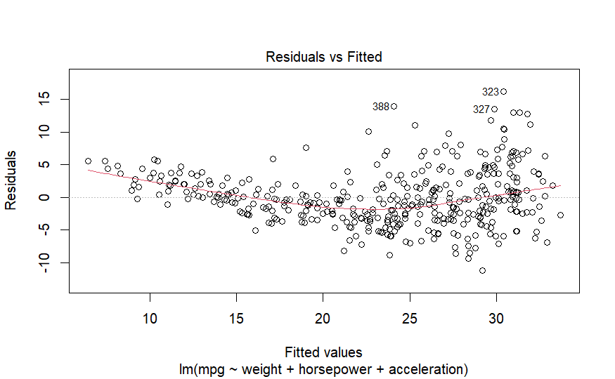

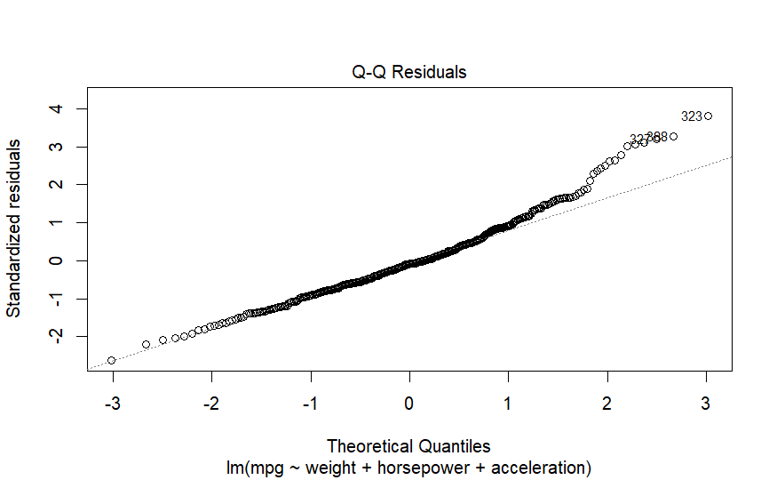

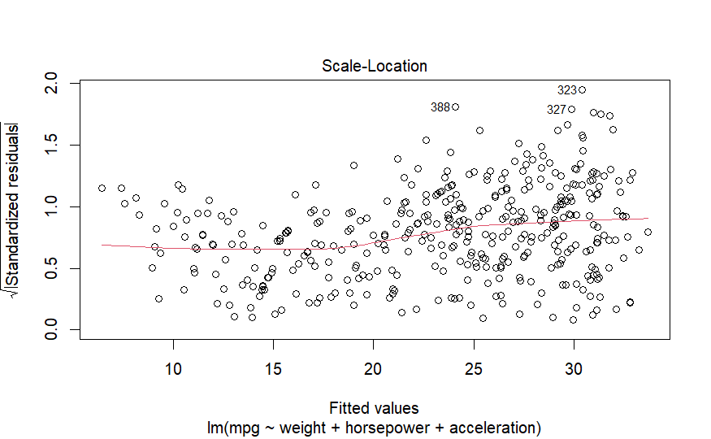

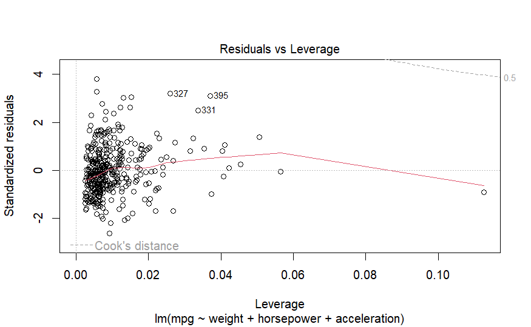

```r
plot(modelo_multiple)
```

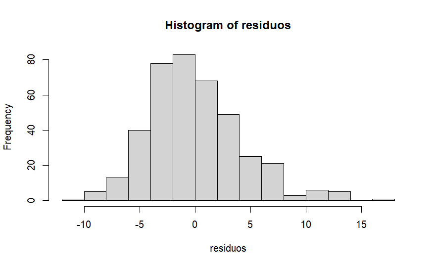

```r
residuos <- residuals(modelo_multiple)
hist(residuos)
```

## Se puede observar una clara heterosticidad, la distribucion normal de los residuos se mira bien, por lo que se realizara una transformacion

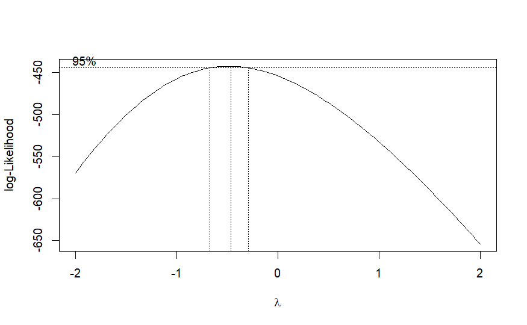

```r
bc <- boxcox(mpg ~ weight + horsepower + acceleration,data=df)
```

```r
(verosimilitud_maxima <- which.max(bc$y))
```

```
[1] 39
```

```r
(lambda <- bc$x[verosimilitud_maxima])
```

```
[1] -0.4646465
```

```r
(df <- df %>%
   mutate(mpg_bc_mult = (mpg^lambda-1/lambda)))
```

| mpg | cylinders | displacement | horsepower | weight | acceleration | model.year | origin | car.name | mpg_bc | mpg_bc_mult |
| --- | --- | --- | --- | --- | --- | --- | --- | --- | --- | --- |
| 18.0 | 8 | 307.0 | 130.0000 | 3504 | 12.0 | 70 | 1 | chevrolet chevelle malibu | 3.282357 | 2.413235 |
| 15.0 | 8 | 350.0 | 165.0000 | 3693 | 11.5 | 70 | 1 | buick skylark 320 | 3.306304 | 2.436315 |
| 18.0 | 8 | 318.0 | 150.0000 | 3436 | 11.0 | 70 | 1 | plymouth satellite | 3.282357 | 2.413235 |
| 16.0 | 8 | 304.0 | 150.0000 | 3433 | 12.0 | 70 | 1 | amc rebel sst | 3.297655 | 2.427920 |
| 17.0 | 8 | 302.0 | 140.0000 | 3449 | 10.5 | 70 | 1 | ford torino | 3.289704 | 2.420261 |
| 15.0 | 8 | 429.0 | 198.0000 | 4341 | 10.0 | 70 | 1 | ford galaxie 500 | 3.306304 | 2.436315 |
| 14.0 | 8 | 454.0 | 220.0000 | 4354 | 9.0 | 70 | 1 | chevrolet impala | 3.315764 | 2.445571 |
| 14.0 | 8 | 440.0 | 215.0000 | 4312 | 8.5 | 70 | 1 | plymouth fury iii | 3.315764 | 2.445571 |
| 14.0 | 8 | 455.0 | 225.0000 | 4425 | 10.0 | 70 | 1 | pontiac catalina | 3.315764 | 2.445571 |
| 15.0 | 8 | 390.0 | 190.0000 | 3850 | 8.5 | 70 | 1 | amc ambassador dpl | 3.306304 | 2.436315 |

[output cut: 388 more lines]

```r
modelo_multiple_bc <- lm(mpg_bc_mult ~ weight + horsepower + acceleration,data=df)
summary(modelo_multiple_bc)
```

```
Call:
lm(formula = mpg_bc_mult ~ weight + horsepower + acceleration,
    data = df)

Residuals:
      Min        1Q    Median        3Q       Max
-0.050224 -0.011365  0.000140  0.009929  0.051874

Coefficients:
              Estimate Std. Error t value Pr(>|t|)
(Intercept)  2.267e+00  9.356e-03 242.270  < 2e-16 ***
weight       2.690e-05  2.208e-06  12.183  < 2e-16 ***
horsepower   3.547e-04  6.100e-05   5.815 1.26e-08 ***
acceleration 5.310e-04  4.736e-04   1.121    0.263
---
Signif. codes:  0 ‘***’ 0.001 ‘**’ 0.01 ‘*’ 0.05 ‘.’ 0.1 ‘ ’ 1

Residual standard error: 0.01684 on 394 degrees of freedom
Multiple R-squared:  0.8076,    Adjusted R-squared:  0.8062
F-statistic: 551.4 on 3 and 394 DF,  p-value: < 2.2e-16
```

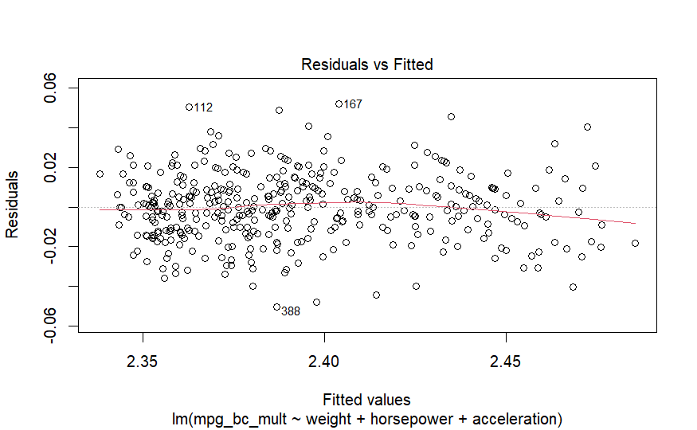

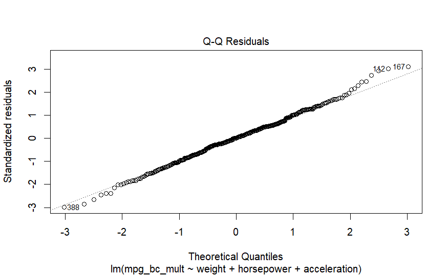

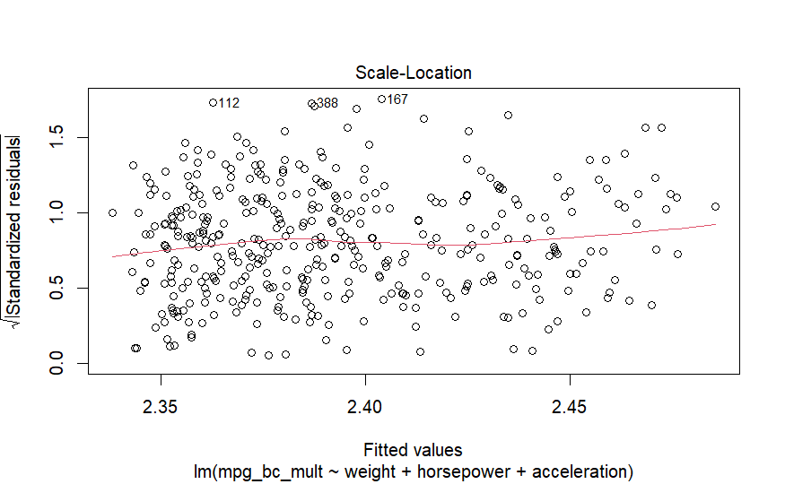

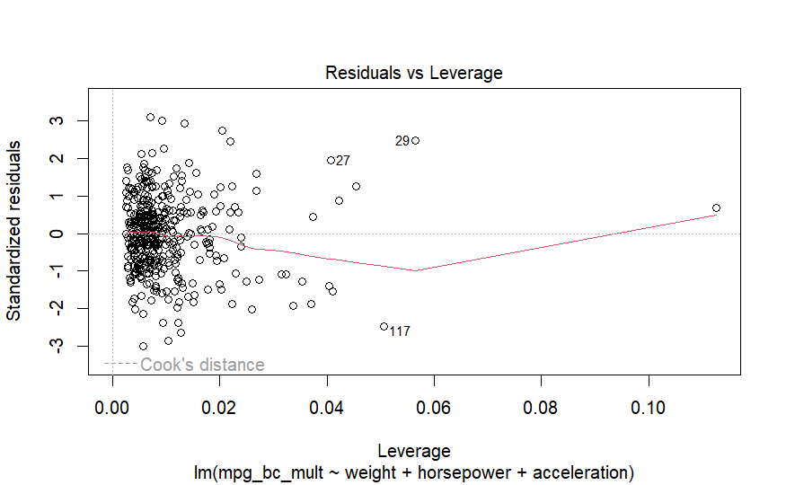

```r
plot(modelo_multiple_bc)
```

## al realizar la transformacion box-cox sobre la variable mpg con el modelo multiple, se elimino la heterocticidad, dando una mejor grafica en los residuos.

```r
colnames(df)
```

```
 [1] "mpg"          "cylinders"    "displacement" "horsepower"   "weight"       "acceleration" "model.year"
 [8] "origin"       "car.name"     "mpg_bc"       "mpg_bc_mult"
```

```r
library(corrplot)
```

```r
df2 <- df %>%
  dplyr::select("mpg","mpg_bc_mult", "horsepower", "weight","acceleration")

(matriz <- cor(df2))
```

```
                    mpg mpg_bc_mult horsepower     weight acceleration
mpg           1.0000000  -0.9651209 -0.7714371 -0.8317409    0.4202889
mpg_bc_mult  -0.9651209   1.0000000  0.8408090  0.8846906   -0.4528527
horsepower   -0.7714371   0.8408090  1.0000000  0.8605743   -0.6842591
weight       -0.8317409   0.8846906  0.8605743  1.0000000   -0.4174573
acceleration  0.4202889  -0.4528527 -0.6842591 -0.4174573    1.0000000
```

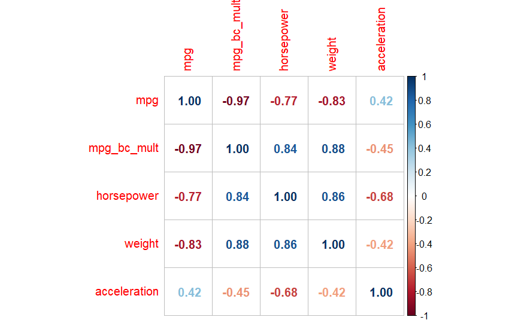

```r
corrplot(cor(df2), method = "number")
```

```r
NA
```

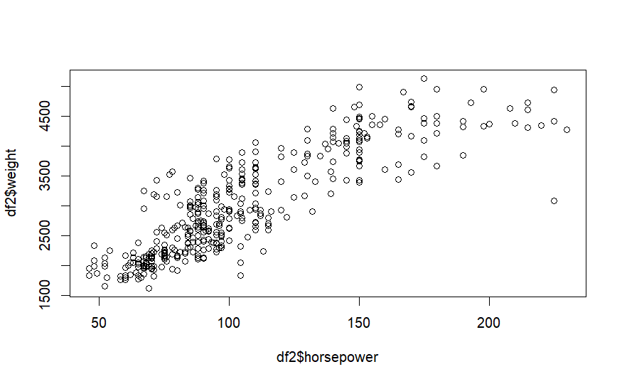

```r
plot(df2$horsepower, df2$weight )
```

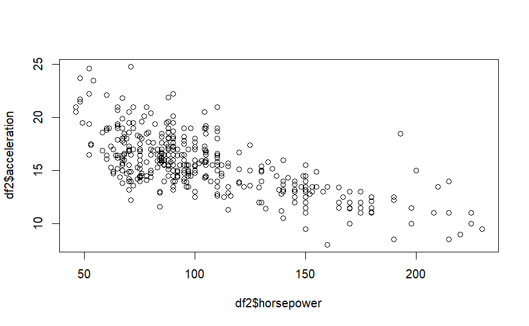

```r
plot(df2$horsepower, df2$acceleration )
```

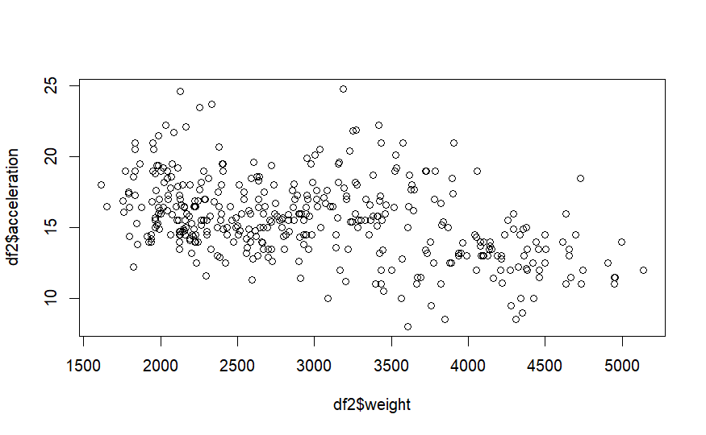

```r
plot(df2$weight, df2$acceleration )
```

## Como se puede observar hay una alta multicolinealidad entre horsepower y weight, por lo que se eliminara horsepower y tambien accelearation ya que en el modelo aporta muy poco estadisticamente. por lo que es necesario analizar otras variables independientes

```r
library(glmnet)
```

```r
(independientes <- setdiff(colnames(df),c("car.name","mpg_bc","mpg_bc_mult")))
```

```
[1] "mpg"          "cylinders"    "displacement" "horsepower"   "weight"       "acceleration" "model.year"   "origin"
```

```r
library("caret")
```

```r
set.seed(12345)
caret::train(mpg ~ .
             , data = df[,independientes]
             , method = "glmnet"
             )
```

```
glmnet

398 samples
  7 predictor

No pre-processing
Resampling: Bootstrapped (25 reps)
Summary of sample sizes: 398, 398, 398, 398, 398, 398, ...
Resampling results across tuning parameters:

  alpha  lambda     RMSE      Rsquared   MAE
  0.10   0.0129854  3.465218  0.8085573  2.623431
  0.10   0.1298540  3.457609  0.8097080  2.596332
  0.10   1.2985404  3.579565  0.8010680  2.642108
  0.55   0.0129854  3.462293  0.8088906  2.619676
  0.55   0.1298540  3.450987  0.8107084  2.583703
  0.55   1.2985404  3.685801  0.8036958  2.728949
  1.00   0.0129854  3.460128  0.8091413  2.616167
  1.00   0.1298540  3.446587  0.8114396  2.578392
  1.00   1.2985404  3.884605  0.8002078  2.911525

RMSE was used to select the optimal model using the smallest value.
The final values used for the model were alpha = 1 and lambda = 0.129854.
```

```r
(independientes2 <- setdiff(colnames(df),c("mpg","car.name","mpg_bc","mpg_bc_mult")))
```

```
[1] "cylinders"    "displacement" "horsepower"   "weight"       "acceleration" "model.year"   "origin"
```

```r
x <- as.matrix(df[,independientes2])
y <- df$mpg
```

```r
modelo_lasso <- glmnet(x,y,alpha = 1, lambda = 0.129854)
coef(modelo_lasso)
```

```
8 x 1 sparse Matrix of class "dgCMatrix"
                        s0
(Intercept)  -15.429564227
cylinders      .
displacement   .
horsepower    -0.005185471
weight        -0.005741837
acceleration   0.016505905
model.year     0.718047846
origin         1.084476743
```

```r
df3 <- df %>%
  dplyr::select("mpg" ,"cylinders","displacement","horsepower","weight","acceleration","model.year","origin" )

(matriz <- cor(df3))
```

```
                    mpg  cylinders displacement horsepower     weight acceleration model.year     origin
mpg           1.0000000 -0.7753963   -0.8042028 -0.7714371 -0.8317409    0.4202889  0.5792671  0.5634504
cylinders    -0.7753963  1.0000000    0.9507214  0.8389394  0.8960168   -0.5054195 -0.3487458 -0.5625433
displacement -0.8042028  0.9507214    1.0000000  0.8936462  0.9328241   -0.5436841 -0.3701642 -0.6094094
horsepower   -0.7714371  0.8389394    0.8936462  1.0000000  0.8605743   -0.6842591 -0.4116510 -0.4536693
weight       -0.8317409  0.8960168    0.9328241  0.8605743  1.0000000   -0.4174573 -0.3065643 -0.5810239
acceleration  0.4202889 -0.5054195   -0.5436841 -0.6842591 -0.4174573    1.0000000  0.2881370  0.2058730
model.year    0.5792671 -0.3487458   -0.3701642 -0.4116510 -0.3065643    0.2881370  1.0000000  0.1806622
origin        0.5634504 -0.5625433   -0.6094094 -0.4536693 -0.5810239    0.2058730  0.1806622  1.0000000
```

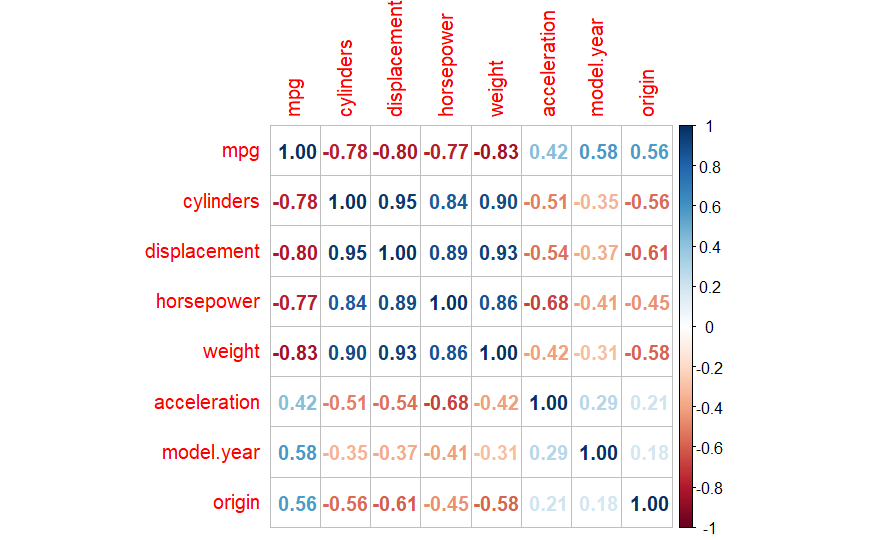

```r
corrplot(cor(df3), method = "number")
```

```r
varImp(modelo_lasso,lambda = 0.0129854)
```

|  | Overall |
| --- | --- |
| cylinders | 0.000000000 |
| displacement | 0.000000000 |
| horsepower | 0.005185471 |
| weight | 0.005741837 |
| acceleration | 0.016505905 |
| model.year | 0.718047846 |
| origin | 1.084476743 |

### Se puede observar claramente la Multicolinealidad entre las variables cylinders,displacement, y que justamente cuando se aplica una regularizaricion del tipo LASSO las elimina., asi tambien como la variable origin puede ser una buena candidata para un nuevo modelo,

# 4. Variables dummy

## Convierte la variable categórica origin en variables dummy.

```r
df$origin <- factor(df$origin)
levels(df$origin)
```

```
[1] "1" "2" "3"
```

```r
modelo_multiple2 <- lm(mpg ~ weight + horsepower +  acceleration + origin,data=df)
summary(modelo_multiple2)
```

```
Call:
lm(formula = mpg ~ weight + horsepower + acceleration + origin,
    data = df)

Residuals:
     Min       1Q   Median       3Q      Max
-12.4353  -2.8373  -0.3749   2.2409  14.8572

Coefficients:
               Estimate Std. Error t value Pr(>|t|)
(Intercept)  42.7932025  2.4166037  17.708  < 2e-16 ***
weight       -0.0050554  0.0006007  -8.415 7.42e-16 ***
horsepower   -0.0486665  0.0152735  -3.186  0.00156 **
acceleration  0.0045517  0.1183273   0.038  0.96934
origin2       1.2262497  0.6401664   1.916  0.05615 .
origin3       2.6982533  0.6520256   4.138 4.29e-05 ***
---
Signif. codes:  0 ‘***’ 0.001 ‘**’ 0.01 ‘*’ 0.05 ‘.’ 0.1 ‘ ’ 1

Residual standard error: 4.19 on 392 degrees of freedom
Multiple R-squared:  0.7162,    Adjusted R-squared:  0.7126
F-statistic: 197.8 on 5 and 392 DF,  p-value: < 2.2e-16
```

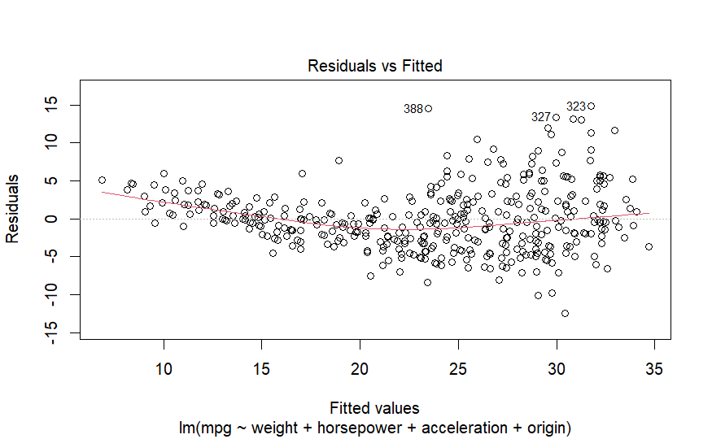

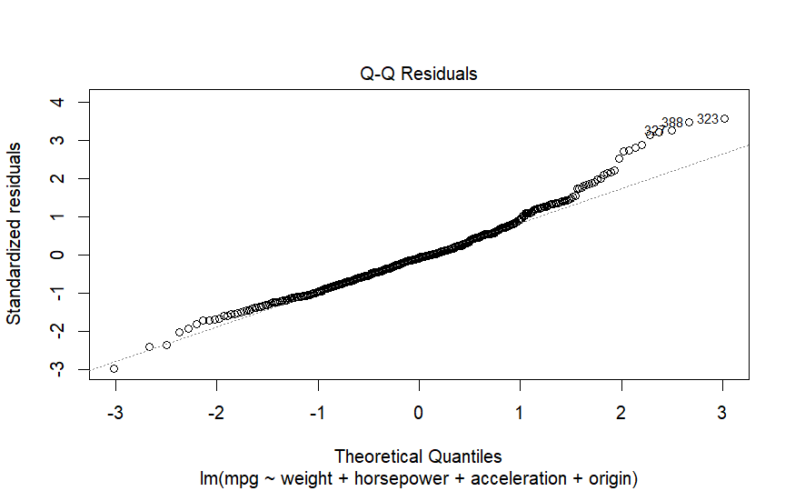

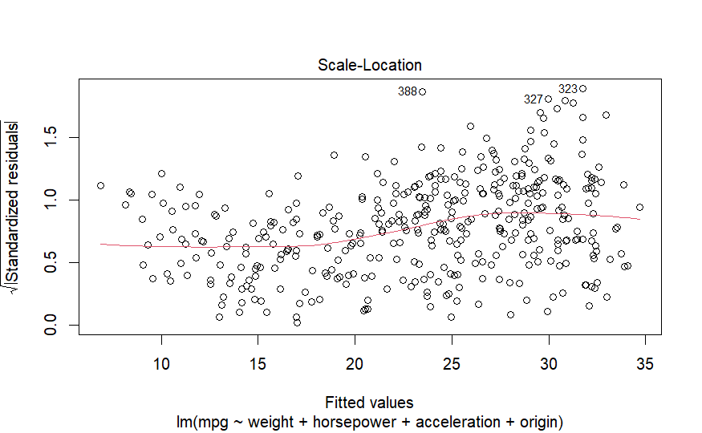

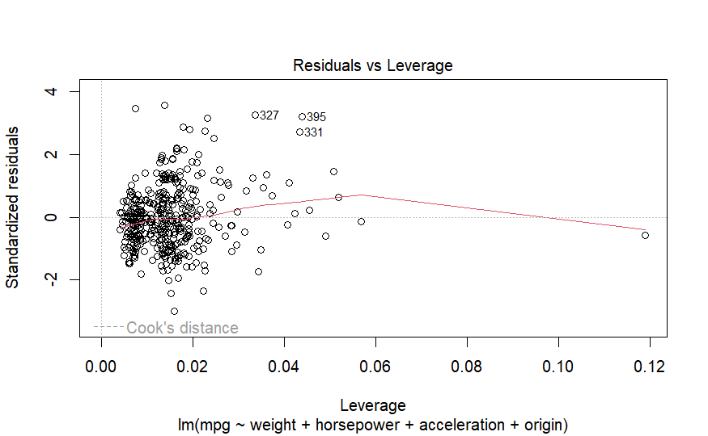

```r
plot(modelo_multiple2)
```

### Se puede observar que los coeficientes de esta variable dummy, cuando el origen es 2 el mpg aumentara 1.226 y cuando el origen es 3 aumentara 2.698 mpg, adema que estas variables en su valor P, la variable origin2 no es significativa para el modelo. vemos que el coeficiente R cuadrado es de 0.71

### aparte se puede ver que en relacion con las demas variables independientes que ya se demostro que hay una multicolinealidad, asi como heterolasticidad, por lo que se verificara como al transformar la variable mpg con este nuevo modelo como se comportara

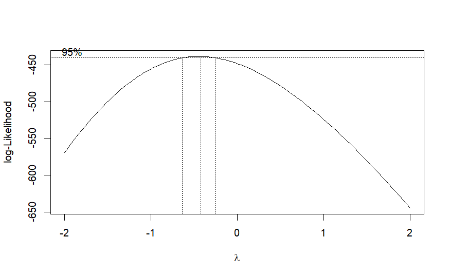

```r
bc <- boxcox(mpg ~ weight + horsepower +  acceleration + origin,data=df)
```

```r
(verosimilitud_maxima <- which.max(bc$y))
```

```
[1] 40
```

```r
(lambda <- bc$x[verosimilitud_maxima])
```

```
[1] -0.4242424
```

```r
(df <- df %>%
   mutate(mpg_bc_mult2 = (mpg^lambda-1/lambda)))
```

| mpg | cylinders | displacement | horsepower | weight | acceleration | model.year | origin | car.name | mpg_bc | mpg_bc_mult | mpg_bc_mult2 |
| --- | --- | --- | --- | --- | --- | --- | --- | --- | --- | --- | --- |
| 18.0 | 8 | 307.0 | 130.0000 | 3504 | 12.0 | 70 | 1 | chevrolet chevelle malibu | 3.282357 | 2.413235 | 2.650543 |
| 15.0 | 8 | 350.0 | 165.0000 | 3693 | 11.5 | 70 | 1 | buick skylark 320 | 3.306304 | 2.436315 | 2.674138 |
| 18.0 | 8 | 318.0 | 150.0000 | 3436 | 11.0 | 70 | 1 | plymouth satellite | 3.282357 | 2.413235 | 2.650543 |
| 16.0 | 8 | 304.0 | 150.0000 | 3433 | 12.0 | 70 | 1 | amc rebel sst | 3.297655 | 2.427920 | 2.665576 |
| 17.0 | 8 | 302.0 | 140.0000 | 3449 | 10.5 | 70 | 1 | ford torino | 3.289704 | 2.420261 | 2.657745 |
| 15.0 | 8 | 429.0 | 198.0000 | 4341 | 10.0 | 70 | 1 | ford galaxie 500 | 3.306304 | 2.436315 | 2.674138 |
| 14.0 | 8 | 454.0 | 220.0000 | 4354 | 9.0 | 70 | 1 | chevrolet impala | 3.315764 | 2.445571 | 2.683553 |
| 14.0 | 8 | 440.0 | 215.0000 | 4312 | 8.5 | 70 | 1 | plymouth fury iii | 3.315764 | 2.445571 | 2.683553 |
| 14.0 | 8 | 455.0 | 225.0000 | 4425 | 10.0 | 70 | 1 | pontiac catalina | 3.315764 | 2.445571 | 2.683553 |
| 15.0 | 8 | 390.0 | 190.0000 | 3850 | 8.5 | 70 | 1 | amc ambassador dpl | 3.306304 | 2.436315 | 2.674138 |

[output cut: 388 more lines]

```r
modelo_multiple_bc2 <- lm(mpg_bc_mult2 ~ weight + horsepower + acceleration + origin,data=df)
summary(modelo_multiple_bc2)
```

```
Call:
lm(formula = mpg_bc_mult2 ~ weight + horsepower + acceleration +
    origin, data = df)

Residuals:
      Min        1Q    Median        3Q       Max
-0.054069 -0.011626  0.000559  0.011097  0.055772

Coefficients:
               Estimate Std. Error t value Pr(>|t|)
(Intercept)   2.507e+00  9.977e-03 251.273  < 2e-16 ***
weight        2.516e-05  2.480e-06  10.146  < 2e-16 ***
horsepower    3.803e-04  6.305e-05   6.031 3.77e-09 ***
acceleration  5.783e-04  4.885e-04   1.184  0.23724
origin2      -3.559e-03  2.643e-03  -1.346  0.17892
origin3      -7.592e-03  2.692e-03  -2.820  0.00504 **
---
Signif. codes:  0 ‘***’ 0.001 ‘**’ 0.01 ‘*’ 0.05 ‘.’ 0.1 ‘ ’ 1

Residual standard error: 0.0173 on 392 degrees of freedom
Multiple R-squared:  0.8102,    Adjusted R-squared:  0.8077
F-statistic: 334.6 on 5 and 392 DF,  p-value: < 2.2e-16
```

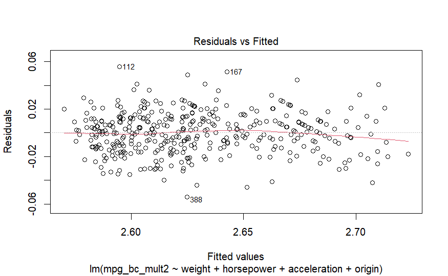

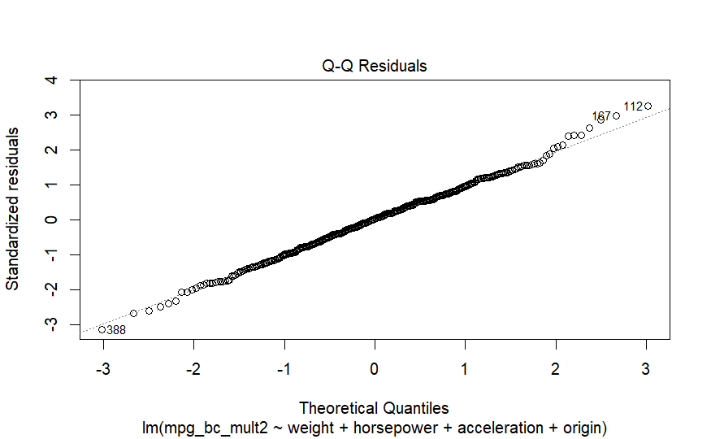

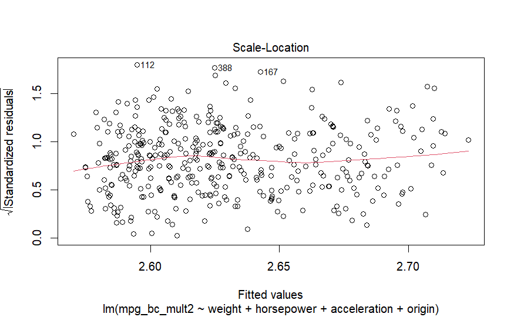

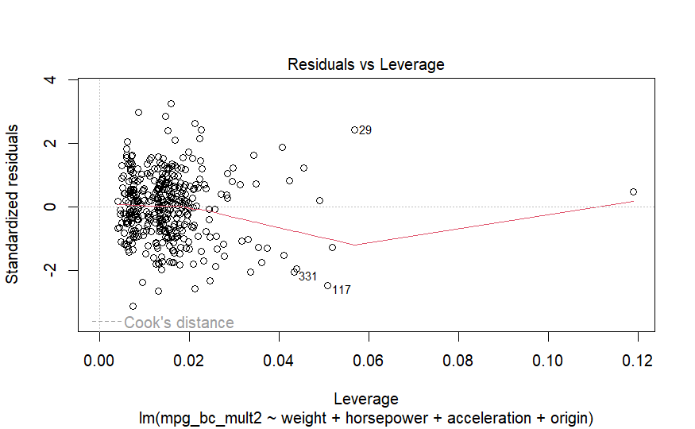

```r
plot(modelo_multiple_bc2)
```

### Vemos que los estimadores de los coeficientes aumentaron y que el valor P de origin2 y acceleration siguen sin ser significativos en el modelo, pero al transformar la variable mpg con este modelo, el coeficiente R cuadrado mejoro,

# 5. Modelo libre

- Realiza un modelo múltiple con cualquier combinación de las variables disponibles.

## Con la matriz de correlacion que se saco anteriormente y con la funcion VarImp se pudieron detectar 2 variables que podrian aportar mas al modelo, las cuales son model.year y origin, eliminando horsepower y acceleration ya que estas no ayudan al modelo

```r
modelo_multiple3 <- lm(mpg ~ weight + model.year + origin,data=df)
summary(modelo_multiple3)
```

[output not shown]

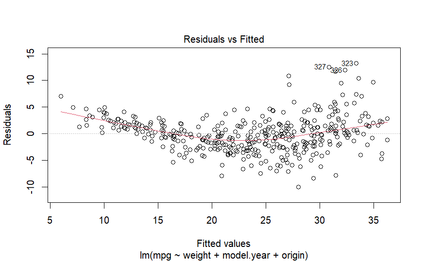

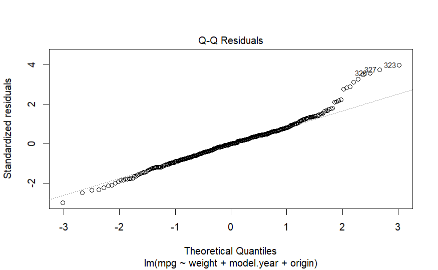

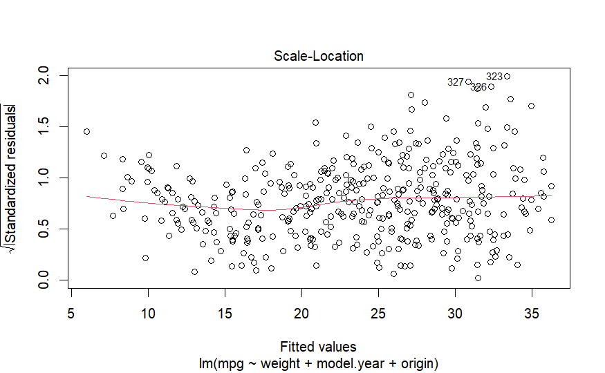

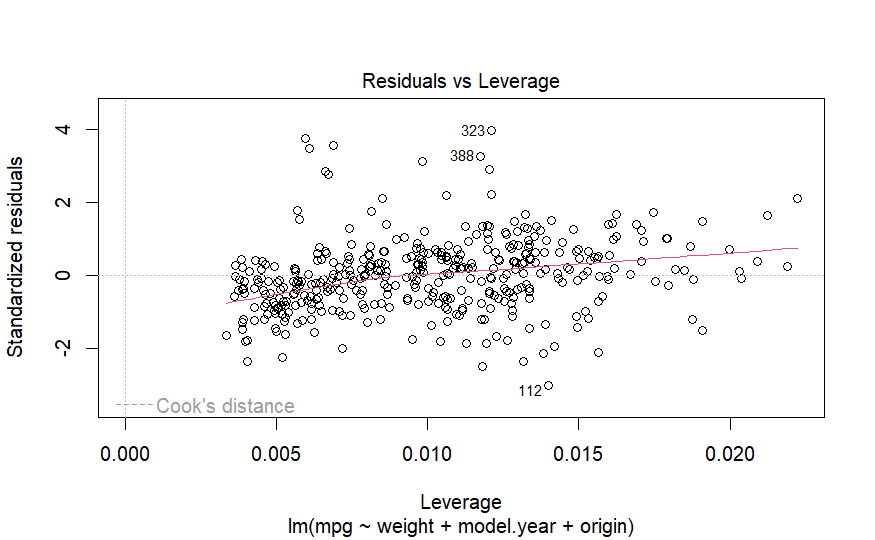

```r
plot(modelo_multiple3)
```

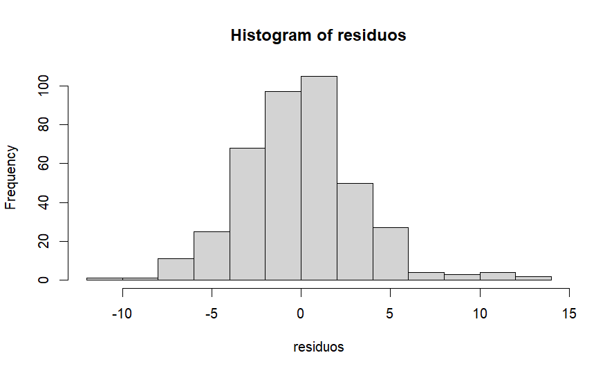

```r
residuos <- residuals(modelo_multiple3)
hist(residuos)
```

### Vemos como sigue habiendo heterolasticidad, lo cual con la transformacion podra mejorar el modelo, eliminando el mismo.

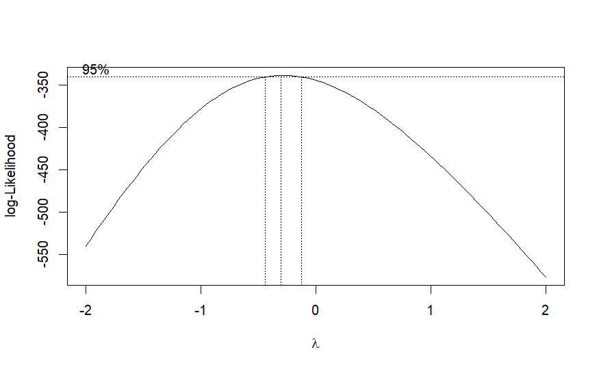

```r
bc <- boxcox(mpg ~ weight + model.year + origin,data=df)
```

```r
(verosimilitud_maxima <- which.max(bc$y))
```

```
[1] 43
```

```r
(lambda <- bc$x[verosimilitud_maxima])
```

```
[1] -0.3030303
```

```r
(df <- df %>%
   mutate(mpg_bc_mult3 = (mpg^lambda-1/lambda)))
```

| mpg | cylinders | displacement | horsepower | weight | acceleration | model.year | origin | car.name | mpg_bc | mpg_bc_mult | mpg_bc_mult2 | mpg_bc_mult3 |
| --- | --- | --- | --- | --- | --- | --- | --- | --- | --- | --- | --- | --- |
| 18.0 | 8 | 307.0 | 130.0000 | 3504 | 12.0 | 70 | 1 | chevrolet chevelle malibu | 3.282357 | 2.413235 | 2.650543 | 3.716499 |
| 15.0 | 8 | 350.0 | 165.0000 | 3693 | 11.5 | 70 | 1 | buick skylark 320 | 3.306304 | 2.436315 | 2.674138 | 3.740158 |
| 18.0 | 8 | 318.0 | 150.0000 | 3436 | 11.0 | 70 | 1 | plymouth satellite | 3.282357 | 2.413235 | 2.650543 | 3.716499 |
| 16.0 | 8 | 304.0 | 150.0000 | 3433 | 12.0 | 70 | 1 | amc rebel sst | 3.297655 | 2.427920 | 2.665576 | 3.731634 |
| 17.0 | 8 | 302.0 | 140.0000 | 3449 | 10.5 | 70 | 1 | ford torino | 3.289704 | 2.420261 | 2.657745 | 3.723776 |
| 15.0 | 8 | 429.0 | 198.0000 | 4341 | 10.0 | 70 | 1 | ford galaxie 500 | 3.306304 | 2.436315 | 2.674138 | 3.740158 |
| 14.0 | 8 | 454.0 | 220.0000 | 4354 | 9.0 | 70 | 1 | chevrolet impala | 3.315764 | 2.445571 | 2.683553 | 3.749457 |
| 14.0 | 8 | 440.0 | 215.0000 | 4312 | 8.5 | 70 | 1 | plymouth fury iii | 3.315764 | 2.445571 | 2.683553 | 3.749457 |
| 14.0 | 8 | 455.0 | 225.0000 | 4425 | 10.0 | 70 | 1 | pontiac catalina | 3.315764 | 2.445571 | 2.683553 | 3.749457 |
| 15.0 | 8 | 390.0 | 190.0000 | 3850 | 8.5 | 70 | 1 | amc ambassador dpl | 3.306304 | 2.436315 | 2.674138 | 3.740158 |

[output cut: 388 more lines]

```r
modelo_multiple_bc3 <- lm(mpg_bc_mult3 ~ weight + model.year + origin,data=df)
summary(modelo_multiple_bc3)
```

```
Call:
lm(formula = mpg_bc_mult3 ~ weight + model.year + origin, data = df)

Residuals:
      Min        1Q    Median        3Q       Max
-0.042334 -0.008312 -0.001352  0.008080  0.053653

Coefficients:
              Estimate Std. Error t value Pr(>|t|)
(Intercept)  3.874e+00  1.657e-02 233.882  < 2e-16 ***
weight       3.524e-05  1.078e-06  32.689  < 2e-16 ***
model.year  -3.735e-03  2.008e-04 -18.598  < 2e-16 ***
origin2     -7.944e-03  2.138e-03  -3.715 0.000233 ***
origin3     -5.369e-03  2.157e-03  -2.489 0.013224 *
---
Signif. codes:  0 ‘***’ 0.001 ‘**’ 0.01 ‘*’ 0.05 ‘.’ 0.1 ‘ ’ 1

Residual standard error: 0.01397 on 393 degrees of freedom
Multiple R-squared:  0.8835,    Adjusted R-squared:  0.8823
F-statistic: 745.3 on 4 and 393 DF,  p-value: < 2.2e-16
```

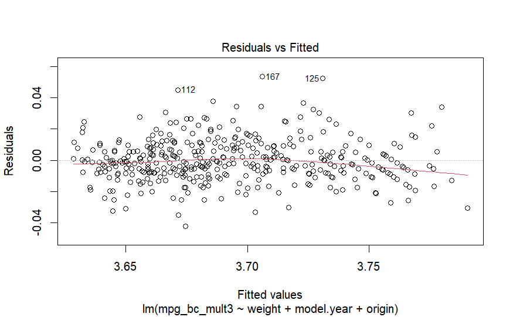

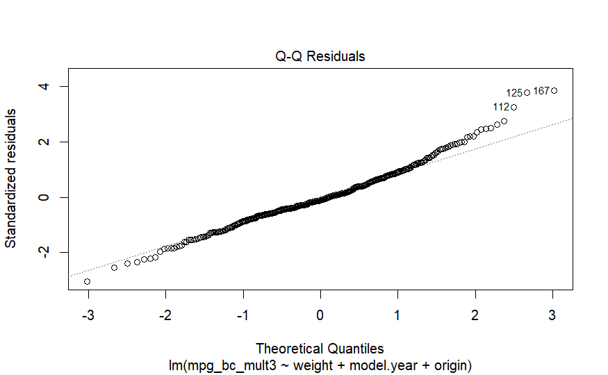

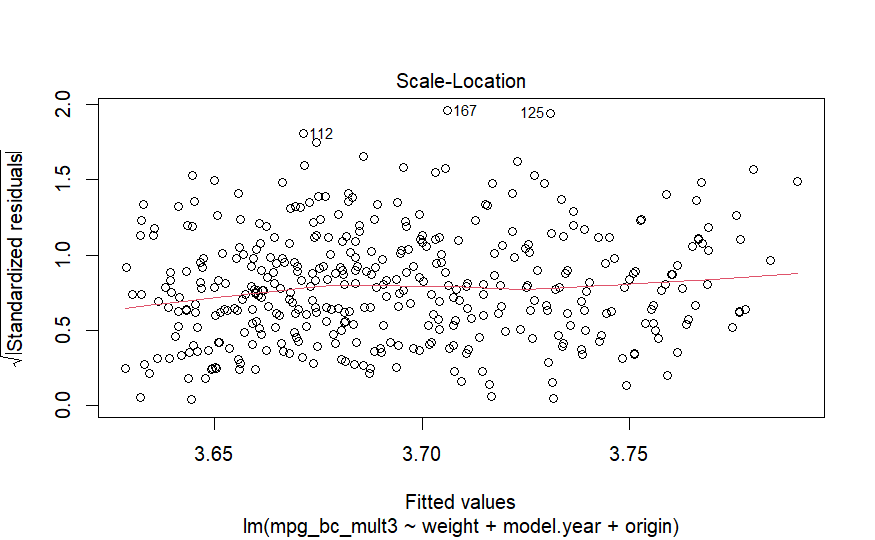

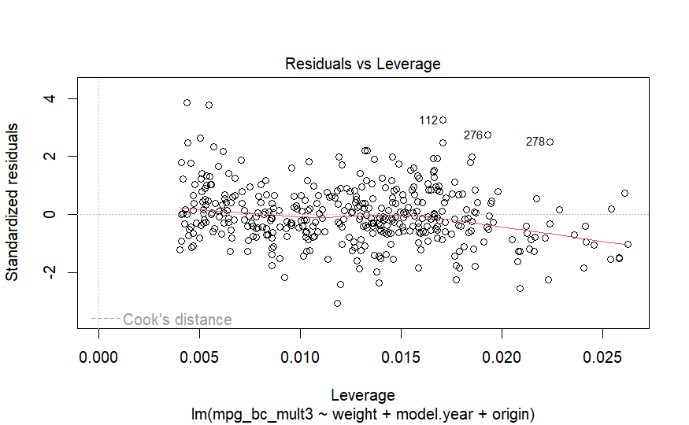

```r
plot(modelo_multiple_bc3)
```

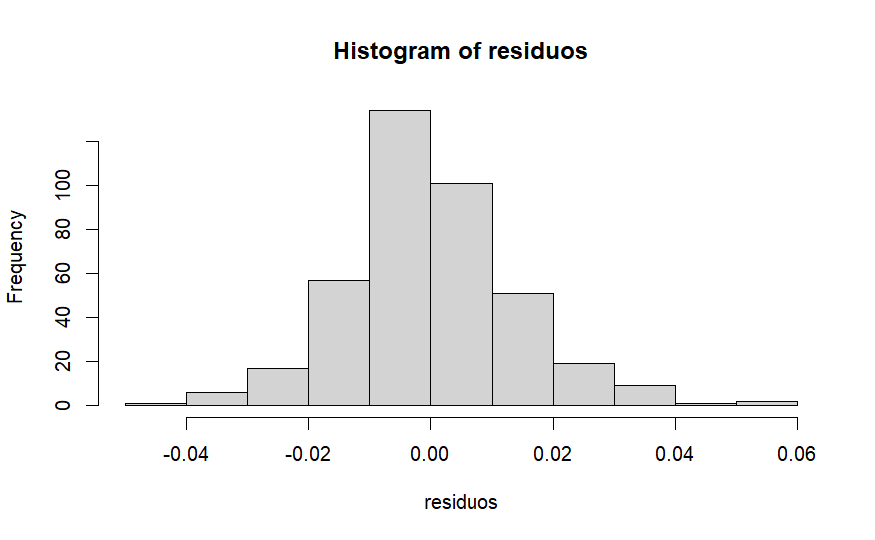

```r
residuos <- residuals(modelo_multiple_bc3)
hist(residuos)
```

### Se puede observar que el cambio es mejor que el coeficiente R Cuadrado es 0.88 y que todas las variables aportan significativamente al modelo.

```r
# Revertir la columna `origin` a numeric
df$origin <- as.numeric(df$origin)
```

```r
df2 <- df %>%
  dplyr::select("mpg","weight", "origin", "model.year")

(matriz <- cor(df2))
```

```
                  mpg     weight     origin model.year
mpg         1.0000000 -0.8317409  0.5634504  0.5792671
weight     -0.8317409  1.0000000 -0.5810239 -0.3065643
origin      0.5634504 -0.5810239  1.0000000  0.1806622
model.year  0.5792671 -0.3065643  0.1806622  1.0000000
```

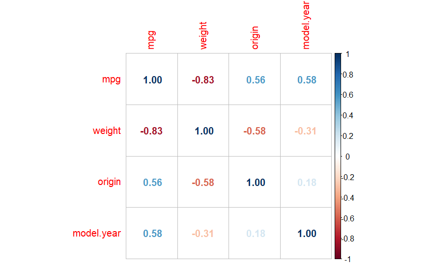

```r
corrplot( cor(df2), method = "number")
```

### Se puede observar que no hay multicolinealidad entra las variables del modelo

### Al transformar la variable dependiente con el nuevo modelo, vemos como el coeficiente de Adjusted R-squared: 0.8823, podemos percatarnos que con la grafica de residuos hay homolasticidad, asi como mejoro la Grafica Q_Q de Residuo, Tambien vemos como la distribucion normal es mas pareja, no hay sesgo